# Homework 1

Statistical Learning - UC3M

Marina Gómez Rey

11-2022

# Include the Dataset

First of all, the libraries are going to be added.

```r
library(tidyverse)
library(leaflet)
library(rgdal)
library(stringr)
library(htmltab)
library(ggplot2)
library(openxlsx)
library(dplyr)
library(factoextra)
library(GGally)
library(cluster)
library(mice)
library(mclust)
library(kernlab)
library(mclust)
```

Now, the dataset is included.

```r
data <- read.xlsx("MOVIE_DATA.xlsx")
```

To see what the dataset is about, let’s display the head of it.

```r
head(data)
```

```
##   color     director_name duration director_facebook_likes
## 1 Color     James Cameron      178                       0
## 2 Color    Gore Verbinski      169                     563
## 3 Color        Sam Mendes      148                       0
## 4 Color Christopher Nolan      164                   22000
## 5  <NA>       Doug Walker       NA                     131
## 6 Color    Andrew Stanton      132                     475
##   actor_3_facebook_likes     actor_2_name actor_1_facebook_likes     gross
## 1                    855 Joel David Moore                   1000 760505847
## 2                   1000    Orlando Bloom                  40000 309404152
## 3                    161     Rory Kinnear                  11000 200074175
## 4                  23000   Christian Bale                  27000 448130642
## 5                     NA       Rob Walker                    131        NA
## 6                    530  Samantha Morton                    640  73058679
##                            genres    actor_1_name
```

[output cut: 34 more lines]

As it can be seen in the variables of the dataset, it talks about films and it combines both categorical values such as the titles, the director, some actors, the country and language, … And also numerical ones like the likes in facebook, the imdb score, the duration, the budget and gross, etc.

Taking into account the previously mentioned variables, the most interesting approach is to study which factors make a film being considered successful. There are several reasons: the economical (how much money the film earned, which is the gross), the social media impact (how many likes it had), and the official score in a webpage using the IMDb one.

With this information, it can also be seen which actors, directors and countries are the most popular and produce the best films.

# 1. Data preprocessing

The first process and one of the most important ones is cleaning the data. In order to do that, some steps described below must be studied and different proceedings are taken to prepare the data for the techniques that will be applied.

**Erase useless columns**

Firstly, there are some variables which seem to not give much information, these are, for example, the names of extra actors and their likes and the users that voted as the results of these votations are not reflected in the dataset. However, to check it, the correlation is plotted.

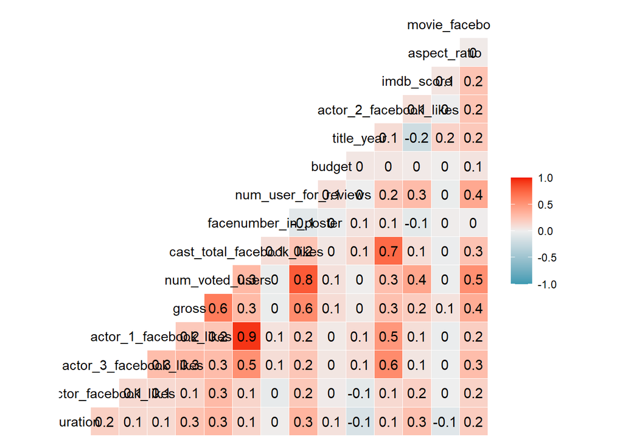

```r
ggcorr(data, label = T)
```

```r
data[5] <- NULL
data[5] <- NULL
data[7] <- NULL
data[9] <- NULL
data[10] <- NULL
data[10] <- NULL
data[10] <- NULL
data[15] <- NULL
data[16] <- NULL
```

**Eliminate duplicates**

First, it has to be checked if there are duplicated values in the movie titles.

```r
sum(table(data$movie_title) - 1)
```

```
## [1] 126
```

There are 126 duplicated values so they are erased.

```r
data <- data[!duplicated(data$movie_title), ]
```

**Changing the types of the variables**

To make sure the numeric variables are numbers, they are converted

```r
data$duration = as.numeric(data$duration)
data$director_facebook_likes = as.numeric(data$director_facebook_likes)
data$actor_1_facebook_likes = as.numeric(data$actor_1_facebook_likes)
data$gross = as.numeric(data$gross)
data$cast_total_facebook_likes = as.numeric(data$cast_total_facebook_likes)
data$budget = as.numeric(data$budget)
data$title_year = as.numeric(data$title_year)
data$imdb_score = as.numeric(data$imdb_score)
data$movie_facebook_likes = as.numeric(data$movie_facebook_likes)
```

**Erasing empty values**

First, we have to check if the empty values exist.

```r
sum(is.na(data))
```

```
## [1] 2022
```

The previous code shows that there are 2022 empty values, which is a large number so they cannot be erased without a previous analysis.

To do that, the empty values graph is computed.

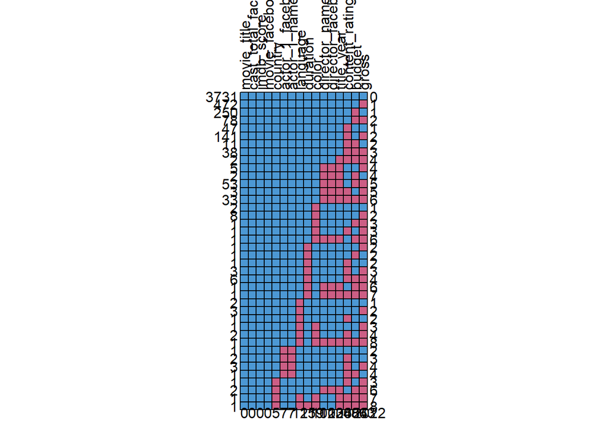

```
##      movie_title cast_total_facebook_likes imdb_score movie_facebook_likes
## 3731           1                         1          1                    1
## 472            1                         1          1                    1
## 250            1                         1          1                    1
## 78             1                         1          1                    1
## 47             1                         1          1                    1
## 141            1                         1          1                    1
## 11             1                         1          1                    1
## 38             1                         1          1                    1
## 2              1                         1          1                    1
## 5              1                         1          1                    1
## 2              1                         1          1                    1
## 53             1                         1          1                    1
## 3              1                         1          1                    1
## 33             1                         1          1                    1
```

[output cut: 153 more lines]

```r
md.pattern(data, rotate.names = TRUE)
```

To see the columns with empty values, the names of the columns are displayed.

```r
names(which(colSums(is.na(data)) > 0))
```

```
##  [1] "color"                   "director_name"
##  [3] "duration"                "director_facebook_likes"
##  [5] "actor_1_facebook_likes"  "gross"
##  [7] "actor_1_name"            "language"
##  [9] "country"                 "content_rating"
## [11] "budget"                  "title_year"
```

That shows useful information, such as there are empty values in categorical variables, which are going to be erased as they are not a high percentage.

```r
data <- data[-which(is.na(data$director_name)),]
data <- data[-which(is.na(data$color)),]
data <- data[-which(is.na(data$actor_1_name)),]
data <- data[-which(is.na(data$language)),]
data <- data[-which(is.na(data$country)),]
data <- data[-which(is.na(data$content_rating)),]
```

Once this has been done, we are going to treat the empty values within numerical variables. Firstly, as there are only two missing values in the Duration one, they are erased.

```r
data <- data[-which(is.na(data$duration)),]
```

Secondly, the gross variable still has 864 empty values. However, as this variable is very important it is better to replace this values with the mean.

```r
mean.gross = mean(data$gross, na.rm = TRUE)
data$gross[is.na(data$gross)] = mean.gross
```

Lastly, the budget variable is also studied. The same as the gross variable happens with this one, so the same actions are taken.

```r
mean.budget = mean(data$budget, na.rm = TRUE)
data$budget[is.na(data$budget)] = mean.budget
```

Now, as all the variables were taken into account, the number of NAs should be 0, and that is going to be checked with the graph.

```r
md.pattern(data, rotate.names = TRUE)
```

```
##  /\     /\
## {  `---'  }
## {  O   O  }
## ==>  V <==  No need for mice. This data set is completely observed.
##  \  \|/  /
##   `-----'
```

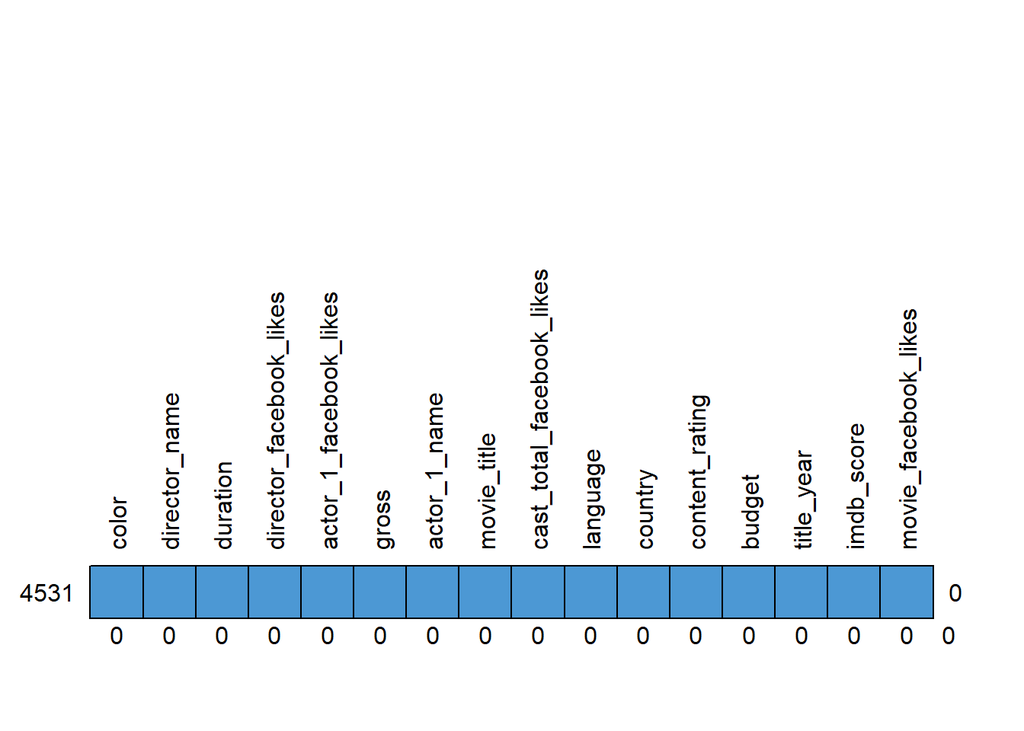

```
##      color director_name duration director_facebook_likes
## 4531     1             1        1                       1
##          0             0        0                       0
##      actor_1_facebook_likes gross actor_1_name movie_title
## 4531                      1     1            1           1
##                           0     0            0           0
##      cast_total_facebook_likes language country content_rating budget
## 4531                         1        1       1              1      1
##                              0        0       0              0      0
##      title_year imdb_score movie_facebook_likes
## 4531          1          1                    1 0
##               0          0                    0 0
```

**Outliers**

As a first approach to outliers, which are extreme values, far from the rest, first a boxplot is computed to see visually if they seem to exist. I decided to test it with the gross variable as I believe this will be an important representative of a film’s success.

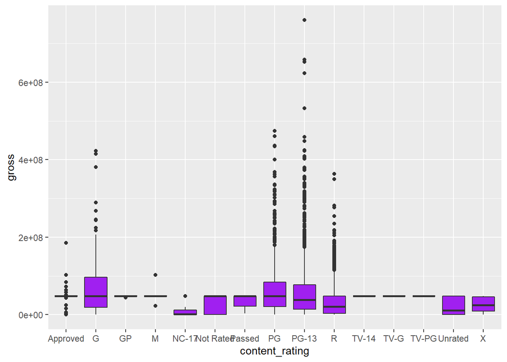

```r
data %>% ggplot(aes(x=content_rating, y=gross)) + geom_boxplot(fill="purple")
```

Clearly, this boxplot shows outliers, so these are going to be studied with the code.

There are two ways of identifying outliers:

The 3-sigma rule, which takes into account the mean and the standard deviation and see which values do not belong to that interval.

```r
mu <- mean(data$gross)
sigma <- sd(data$gross)

sum(data$gross < mu - 3*sigma | data$gross > mu + 3*sigma)
```

```
## [1] 104
```

This test gives as a result a total of 104 outliers.

And the IQR, which takes into account the Inter Quantile Range.

```r
QI <- quantile(data$gross, 0.25)
QS <- quantile(data$gross, 0.75)
IQR = QS-QI

sum(data$gross < QI - 1.5 * IQR | data$gross > QS + 1.5 * IQR)
```

```
## [1] 384
```

This other test gives 384 outliers as a result.

With these results, it has to be decided what to do with the outliers. They do not represent a big percentage of the dataset. Also, it can be possible that a film either produces a lot of benefits or very few. Taking that into account I strongly believe the best decision is to leave them as they can provide useful information regarding the success of a movie.

**Scale the data**

Scaling the data is an useful tool to have between the same ranges all the variables, so this technique is going to be applied with the scale function.

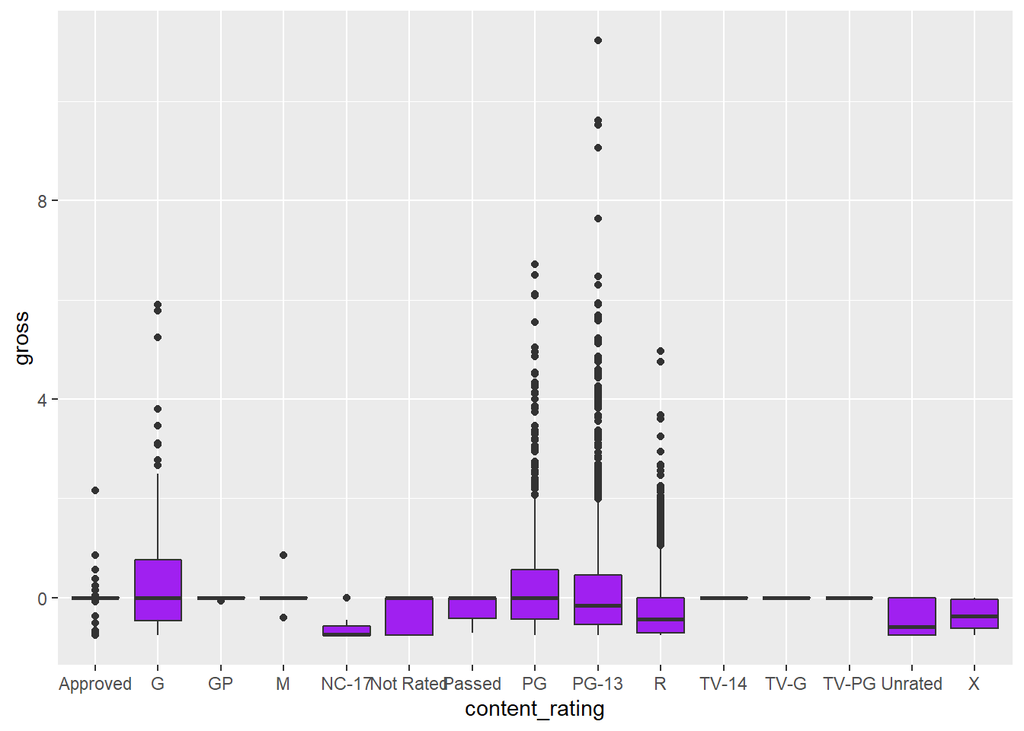

```r
data$duration = scale(data$duration)
data$director_facebook_likes = scale(data$director_facebook_likes)
data$actor_1_facebook_likes = scale(data$actor_1_facebook_likes)
data$gross = scale(data$gross)
data$cast_total_facebook_likes = scale(data$cast_total_facebook_likes)
data$budget = scale(data$budget)
data$imdb_score = scale(data$imdb_score)
data$movie_facebook_likes = scale(data$movie_facebook_likes)

data %>% ggplot(aes(x=content_rating, y=gross)) + geom_boxplot(fill="purple")
```

It can be seen that the graphs do not change.

# 2. Visualization

Visualization can help us making some hypothesis based to questions with a visual tool. To create them the ggplot2 library is used, and they can show relationships between variables.

**Relationship between budget, gross and language**

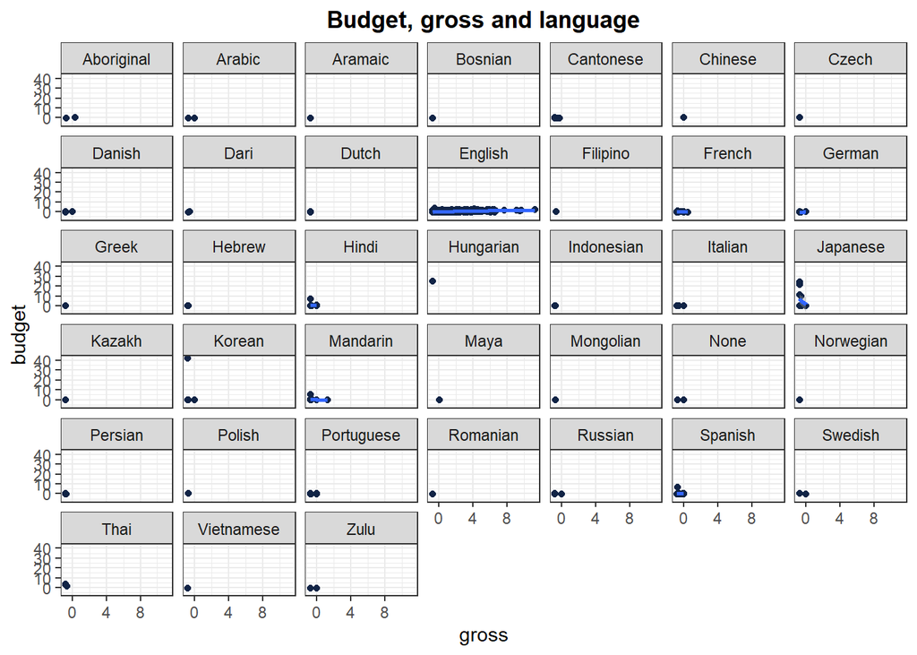

```r
ggplot(data) +
  aes(x = gross, y = budget) +
  geom_point(shape = "circle", size = 1.5, colour = "#112446") +
  geom_smooth(span = 0.75) +
  theme_minimal() +
  facet_wrap(vars(language)) +
  labs(title = "Budget, gross and language") +
  theme_bw() +
  theme(plot.title = element_text(face = "bold", hjust = 0.5))
```

This graph shows that there exists a relation between plus budget equals plus gross, but it is not as strong as someone could think. Also, the other languages with significant values are Hindi, Japanese, Mandarin, Spanish, German and French.

**Relationship between language, countries and color**

As the previous graph shows that English is the main language, I believe it is important to know where are these films made. Also, the relationship with color or black and white films can be also established.

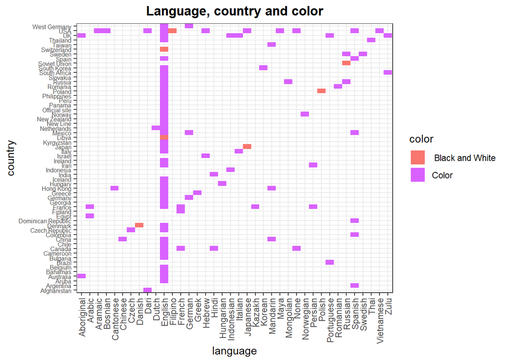

```r
ggplot(data) +
  aes(x = language, y = country, fill = color) +
  geom_tile(size = 1.2) +
  scale_fill_manual(
    values = c(` Black and White` = "#F8766D",
    Color = "#D961FF")
  ) +
  labs(title = "Language, country and color") +
  theme_bw() +
  theme(plot.title = element_text(face = "bold", hjust = 0.5),
        axis.text.x = element_text(angle = 90, vjust = 0.5, hjust = 1),
        axis.text.y = element_text(size = 6))
```

This graph makes obvious that almost all countries film their movies in English, which is a matter of globalization. However, there are countries such as USA that have films in various languages, probably because of multiculturalism. However, they are not expected to be very popular because as shown in the previous graph other languages are not very profitable.

On top of that, it can be seen that only 7 countries have films in black and white, so they are not expected to be very popular or have a big benefit as they do not belong to the countries with better benefits that were established in the previous graph.

**Relationship between gross. movie likes and cast likes**

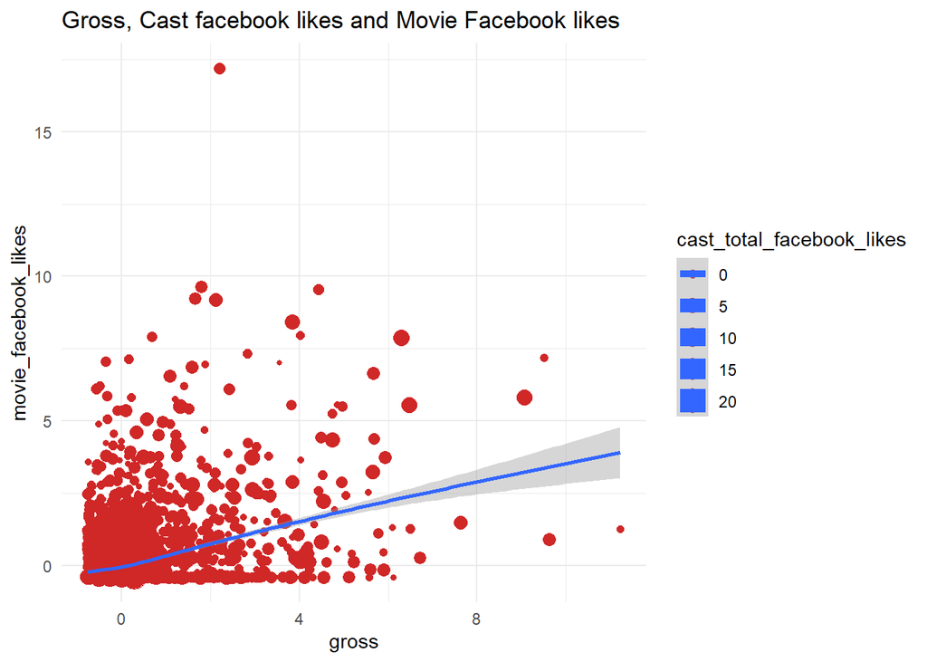

```r
ggplot(data) +
  aes(
    x = gross,
    y = movie_facebook_likes,
    size = cast_total_facebook_likes
  ) +
  geom_point(shape = "circle", colour = "#D02727") +
  geom_smooth(span = 0.75) +
  labs(
    title = "Gross, Cast facebook likes and Movie Facebook likes"
  ) +
  theme_minimal()
```

This graph shows a direct relationship between gross and movie likes in Facebook. However, when relating cast likes and gross, although it seems to exist a little relationship, it is not as clear as someone would expect, as the sizes of the points are not that regular. Something similar happens with cast likes and movie likes. That suggests that movie likes are not completely related with the actors that participate in them, and that the gross depends more on the movie itself that its casting.

**Relationship between gross and content rating**

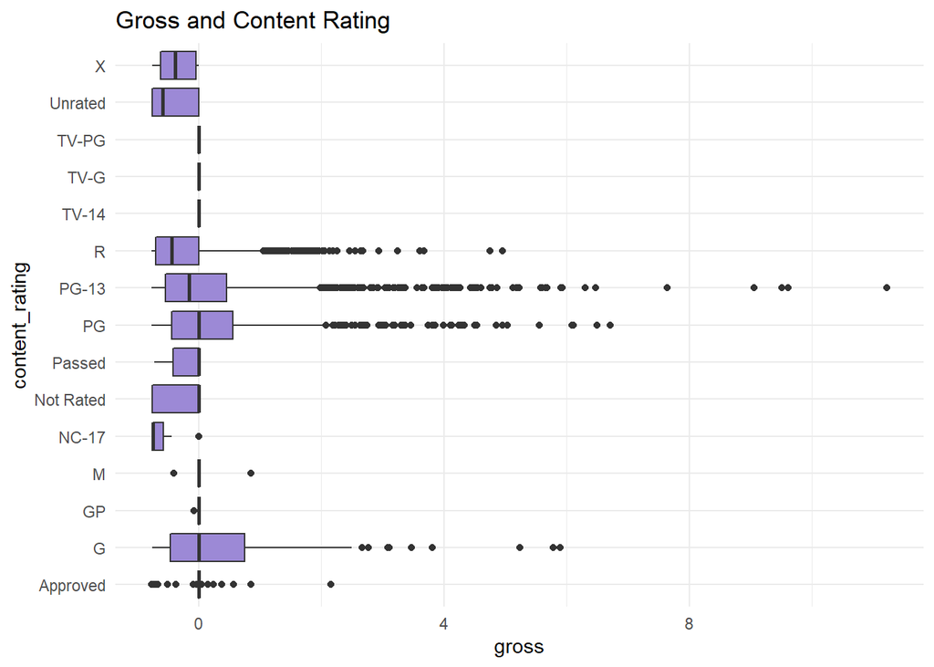

```r
ggplot(data) +
  aes(x = gross, y = content_rating) +
  geom_boxplot(fill = "#9C89D6") +
  labs(title = "Gross and Content Rating") +
  theme_minimal()
```

This boxplots show that the films with the most gross are the ones with a rating of PG, G and PG-13.

These are the General (for every audience, including children) audience, the Parent Guidance (parents should watch it before just in case there is something inappropriate, but normally children can watch them) and PG-13 (not suitable for children under 13). Taking this information into account, it seems that familiar films obtain better results. My belief is that this happens because it has a wider public.

**Relationship between likes**

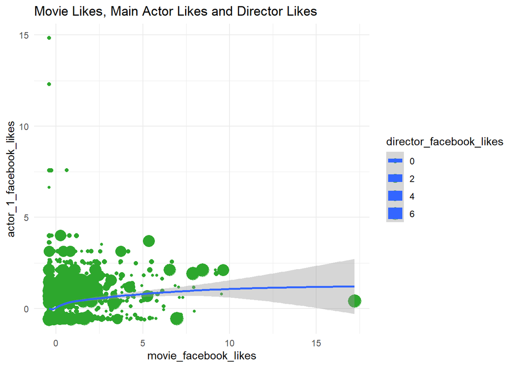

```r
ggplot(data) +
  aes(
    x = movie_facebook_likes,
    y = actor_1_facebook_likes,
    size = director_facebook_likes
  ) +
  geom_point(shape = "circle", colour = "#2DA72D") +
  geom_smooth(span = 0.75) +
  labs(title = "Movie Likes, Main Actor Likes and Director Likes") +
  theme_minimal()
```

It can be seen that there is relationship between the main actor and the movie likes. However, it is not that clear in the director likes, as the size of the points is not regular. There are big points in both few liked movies and better liked ones.

Taking into account the previously computed graph that related the movie facebook likes and the gross, it seems that the likes of the main actor also influence when creating a film with a better gross. This was not sure with the cast likes, but now it has been confirmed. However, the director does not seem that important.

**Relationship between gross, IMDb score and years**

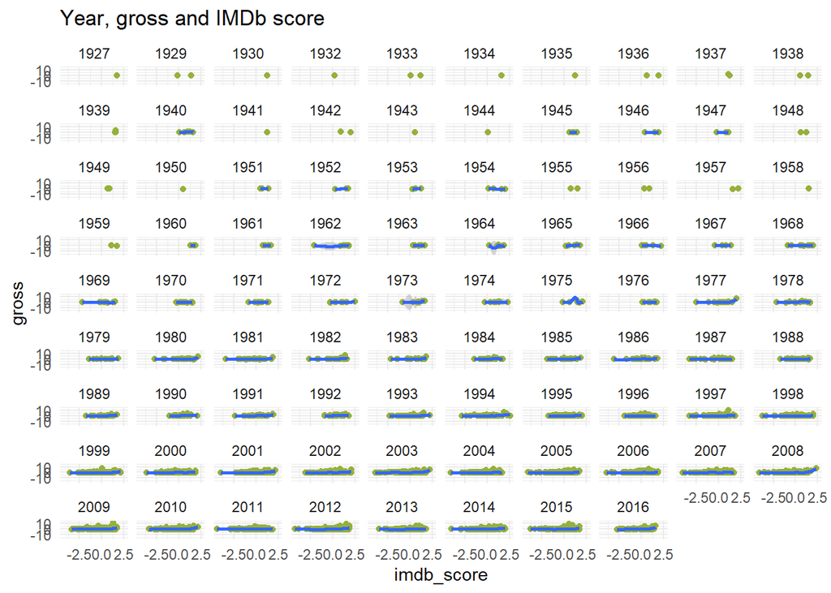

```r
ggplot(data) +
  aes(x = imdb_score, y = gross) +
  geom_point(shape = "circle", size = 1.5, colour = "#96B03A") +
  geom_smooth(span = 0.75) +
  labs(title = "Year, gross and IMDb score") +
  theme_minimal() +
  facet_wrap(vars(title_year))
```

This graph has some curious insights. First of all, it makes obvious the facts that each year has more films than the previous ones. What I think is the most curious is the fact that films from the past, like from years 1938 and 1939, seem to have a big IMDb score. Year 1962 seems to be the inflection point where more films started to be created.

As a relationship between gross and IMDb score, it looks like there is a relationship, as bigger IMDb score values give better gross results.

**Insights on best movies, directors and actors**

To get an insight of which have been the best movies, directors and actors, some graphs with the names in terms of the gross and movie likes are computed.

- Best movies

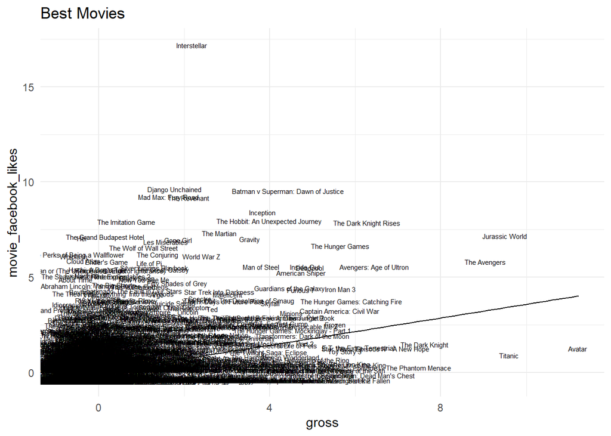

```r
ggplot(data) + aes(x = gross, y = movie_facebook_likes) +
  geom_point(color = "white") +
  geom_text(aes(label = movie_title), size = 2.0, angle = 0) +
  geom_smooth(formula = 'y ~ x', method = "lm", se = F,
              color = "black", size = 0.4) +
  theme(text = element_text(size = 6))+
  labs(title = "Best Movies") +
  theme_minimal()
```

The films that appear at the best positions are, for example: ‘Jurassic World’, ‘The Avengers’, ‘The Hunger games’, ‘The Dark knight rises’, ‘Avatar’, ‘Interstellar’ or ‘Titanic’.

- Best actors

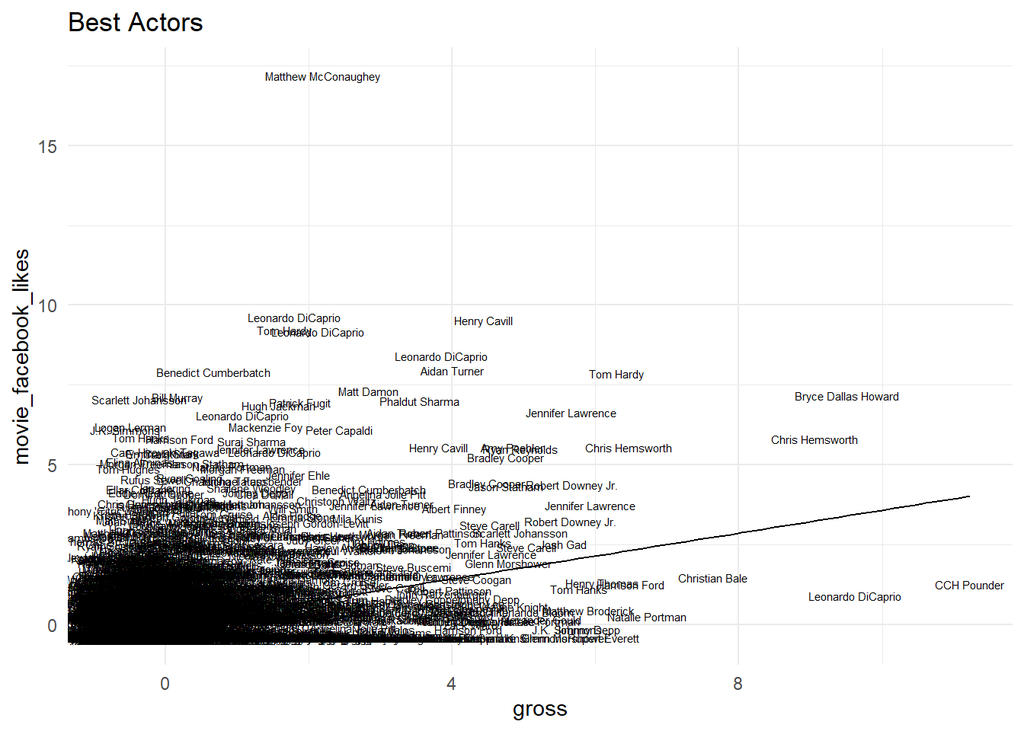

```r
ggplot(data) + aes(x = gross, y = movie_facebook_likes) +
  geom_point(color = "white") +
  geom_text(aes(label = actor_1_name), size = 2.0, angle = 0) +
  geom_smooth(formula = 'y ~ x', method = "lm", se = F,
              color = "black", size = 0.4) +
  theme(text = element_text(size = 6))+
  labs(title = "Best Actors") +
  theme_minimal()
```

The best actors seem to be Chris Hemsworth, Tom Hardy, Bryce Dallas Howard, Matthew McConaughey, Henry Cavill, among others.

- Best directors

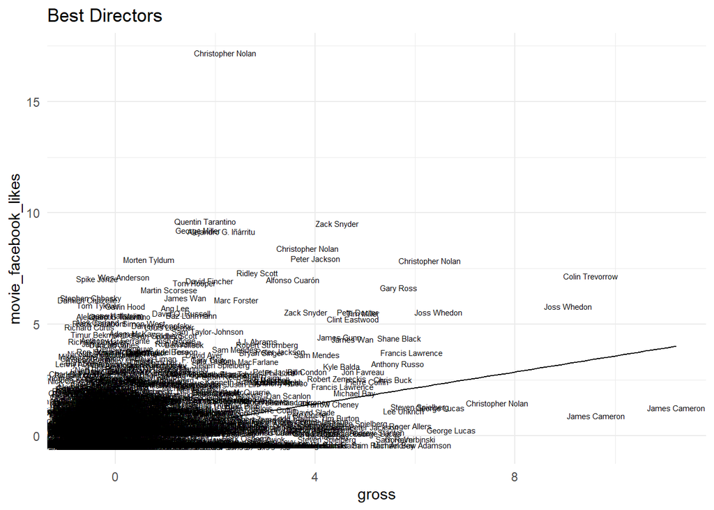

```r
ggplot(data) + aes(x = gross, y = movie_facebook_likes) +
  geom_point(color = "white") +
  geom_text(aes(label = director_name), size = 2.0, angle = 0) +
  geom_smooth(formula = 'y ~ x', method = "lm", se = F,
              color = "black", size = 0.4) +
  theme(text = element_text(size = 6))+
  labs(title = "Best Directors") +
  theme_minimal()
```

Finally, about directors, the best ones are: Chistopher Nolan, Joss Whedon, James Cameron, Colin Trevorrow, etc.

# 3. Principal Component Analysis

Principal Component Analysis is a technique that lets us reduce the number of variables that compose our dataset taking into account their correlations and how much they explain, so the same amount of information is given with less variables.

With this information in mind, PCA can help us to study our primary objective and finding also the best films, actors, directors, etc.

Firstly, a dataframe with the numeric variables is created. Also, the movie titles and the actor and director names, as well as the countries, are saved.

Although the year is a numerical value, I strongly believe that studying which were the most successful years in terms of good films that came out that year is more interesting.

```r
dataframe = data.frame(data$gross, data$duration, data$director_facebook_likes,
                       data$actor_1_facebook_likes, data$cast_total_facebook_likes,
                       data$budget, data$imdb_score, data$movie_facebook_likes)

titles = data$movie_title
directors = data$director_name
actors = data$actor_1_name
countries = data$country
years = data$title_year
```

With the data organised, the PCA can be computed.

```r
pca = prcomp(dataframe, scale = T)
summary(pca)
```

```
## Importance of components:
##                           PC1    PC2    PC3    PC4    PC5     PC6     PC7
## Standard deviation     1.5941 1.1898 1.0179 0.9273 0.9183 0.80783 0.76699
## Proportion of Variance 0.3176 0.1770 0.1295 0.1075 0.1054 0.08157 0.07353
## Cumulative Proportion  0.3176 0.4946 0.6241 0.7316 0.8370 0.91860 0.99213
##                            PC8
## Standard deviation     0.25090
## Proportion of Variance 0.00787
## Cumulative Proportion  1.00000
```

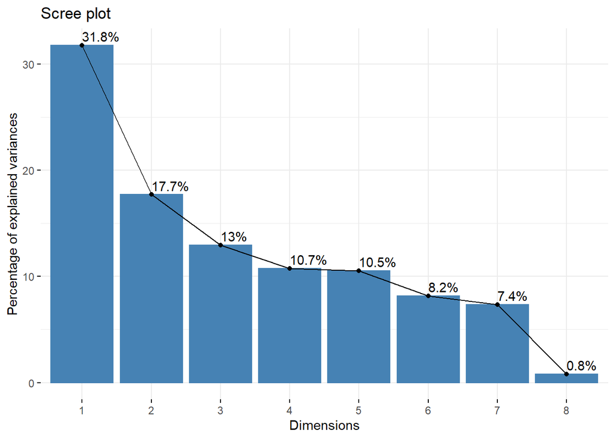

```r
fviz_screeplot(pca, addlabels = TRUE)
```

The scree plot shows that with 4 components almost the 75% of the variance can be described.

For that reason, these 4 dimensions are going to be evaluated, starting with the first one.

**First component**

To see the importance of the variables in this dimension, a graph is going to be computed.

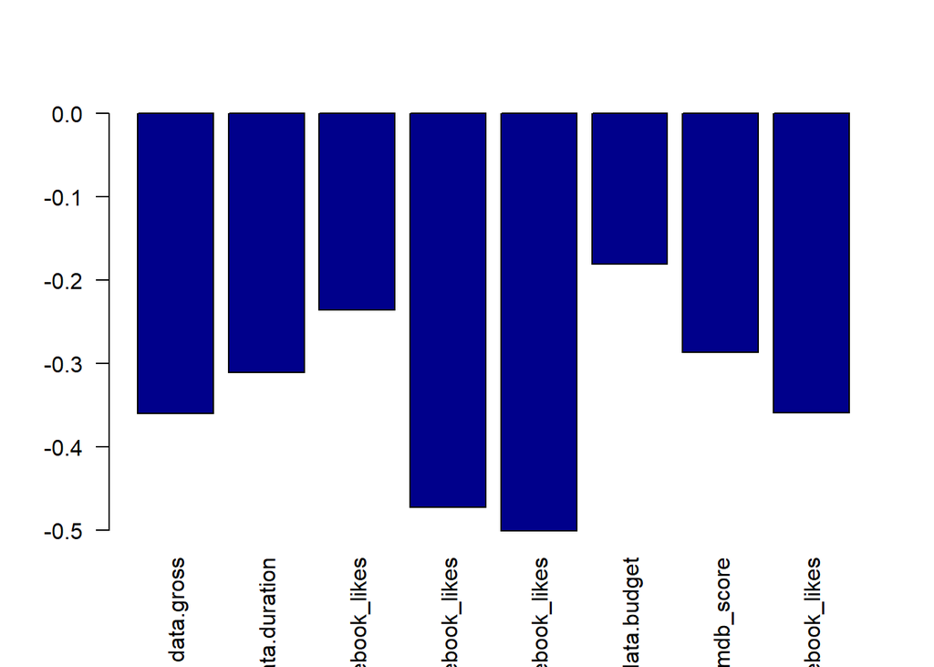

```r
barplot(pca$rotation[,1], las=2, col="darkblue")
```

To see the graph better, as the squared loadings are equal to 1, computing them will show it better.

```r
sum(pca$rotation[,1]^2)
```

```
## [1] 1
```

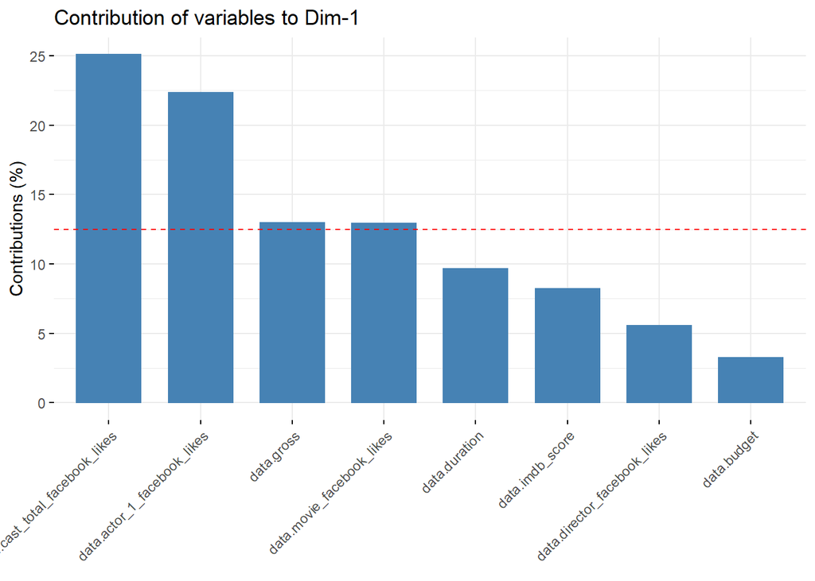

```r
fviz_contrib(pca, choice = "var", axes = 1)
```

With this information, the best and worst films can be shown.

```r
# Best
titles[order(pca$x[,1])][1:10]
```

```
##  [1] "The Final Destination "   "The Dark Knight Rises "
##  [3] "Feast "                   "Interstellar "
##  [5] "Inception "               "The Avengers "
##  [7] "Quarantine "              "Armored "
##  [9] "Avengers: Age of Ultron " "The Dark Knight "
```

```r
# Worst
titles[order(pca$x[,1])][(length(titles) - 9):length(titles)]
```

```
##  [1] "Snow White: A Deadly Summer "  "Marci X "
##  [3] "Crossover "                    "The Vatican Exorcisms "
##  [5] "Who's Your Caddy? "            "Doogal "
##  [7] "Disaster Movie "               "Barney's Great Adventure "
##  [9] "From Justin to Kelly "         "Superbabies: Baby Geniuses 2 "
```

Among the best movies, there are some very recognizable titles such as ‘The dark knight rises’, ‘The avengers’, ‘Interstellar’ or ‘Inception’.

**Second component**

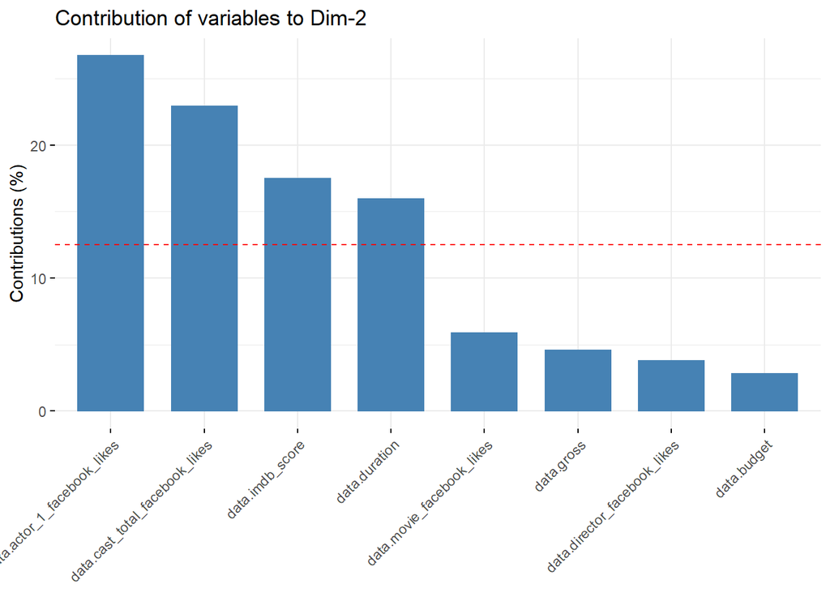

```r
fviz_contrib(pca, choice = "var", axes = 2)
```

The second component analysis gives, again, importance to likes, mainly of the cast and main actor.

However, there are several differences, mainly, the fact that now IMDb score is a very important factor, contrary to the gross, which is lower than the average.

With this information, let’s see if the best and worst films have changed.

```r
# Best
titles[order(pca$x[,2])][1:10]
```

```
##  [1] "The Final Destination " "Feast "                 "Armored "
##  [4] "Quarantine "            "The Amityville Horror " "Shorts "
##  [7] "Evan Almighty "         "Firewall "              "Trucker "
## [10] "Poseidon "
```

```r
# Worst
titles[order(pca$x[,2])][(length(titles) - 9):length(titles)]
```

```
##  [1] "Das Boot "                          "Jurassic World "
##  [3] "Blood In, Blood Out "               "The Hobbit: An Unexpected Journey "
##  [5] "Avatar "                            "Fateless "
##  [7] "Gone Girl "                         "Princess Mononoke "
##  [9] "Interstellar "                      "Lady Vengeance "
```

**Third component**

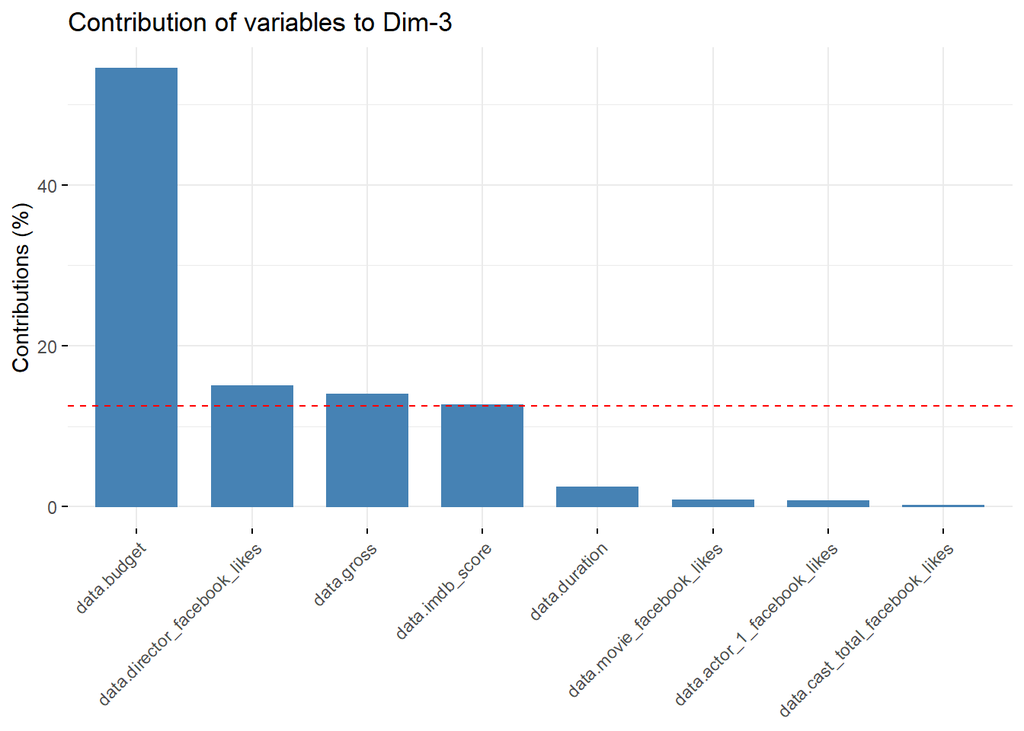

```r
fviz_contrib(pca, choice = "var", axes = 3)
```

The third component gives importance to the budget mainly. It occupies most of the percentage. However, above the median, the director facebook likes, the gross and the IMDb score remain.

Again, let’s see the best and worst films.

```r
# Best
titles[order(pca$x[,3])][1:10]
```

```
##  [1] "Lady Vengeance "         "Fateless "
##  [3] "Princess Mononoke "      "Steamboy "
##  [5] "Godzilla 2000 "          "Akira "
##  [7] "Avatar "                 "Jurassic World "
##  [9] "Tango "                  "Kabhi Alvida Naa Kehna "
```

```r
# Worst
titles[order(pca$x[,3])][(length(titles) - 9):length(titles)]
```

```
##  [1] "Mean Streets "                  "Casino "
##  [3] "Goodfellas "                    "The Last Temptation of Christ "
##  [5] "Don Jon "                       "Raging Bull "
##  [7] "Fight Club "                    "Zodiac "
##  [9] "Memento "                       "The Prestige "
```

The films are different probably because they are based on how much money was used to produced them. For that reason, we still have to study the fourth component.

**Fourth component**

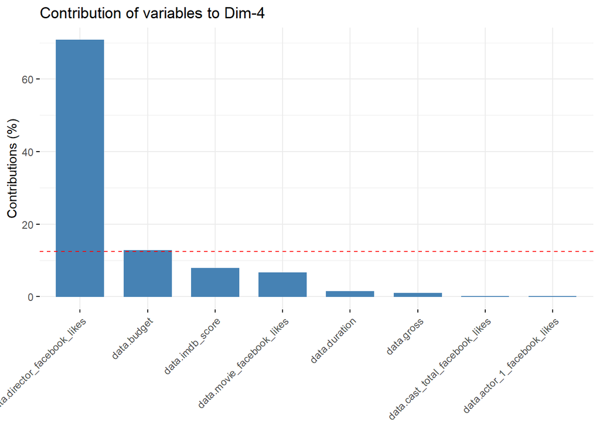

```r
fviz_contrib(pca, choice = "var", axes = 4)
```

This fourth component has more than a 70% on the director likes, which, again, gives importance to social media. The budget is higher than the average but the rest of the variables do not almost appear.

Once again, the best and worst films are obtained.

```r
# Best
titles[order(pca$x[,4])][1:10]
```

```
##  [1] "The Revenant "                       "The Hobbit: An Unexpected Journey "
##  [3] "The Imitation Game "                 "Batman v Superman: Dawn of Justice "
##  [5] "The Avengers "                       "The Martian "
##  [7] "The Hunger Games "                   "Mad Max: Fury Road "
##  [9] "Les Misérables "                     "Jurassic World "
```

```r
# Worst
titles[order(pca$x[,4])][(length(titles) - 9):length(titles)]
```

```
##  [1] "The Curious Case of Benjamin Button "
##  [2] "Batman Begins "
##  [3] "Panic Room "
##  [4] "Alien 3 "
##  [5] "Insomnia "
##  [6] "Don Jon "
##  [7] "Steamboy "
##  [8] "Fateless "
##  [9] "Princess Mononoke "
## [10] "Lady Vengeance "
```

Again the films change as they are almost only based on the director likes.

**Individual contribution**

Once we have the previous information, we can see how the films contribute individually to the total result.

This contribution is a representation of which are the best films until 2016.

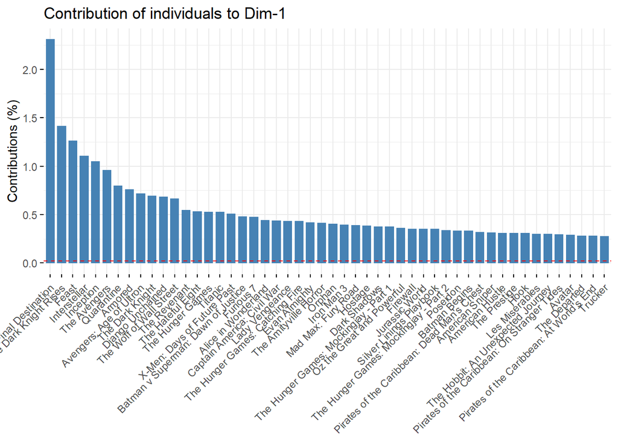

```r
titles_z1 = titles[order(get_pca_ind(pca)$contrib[,1],decreasing=T)]

fviz_contrib(pca, choice = "ind", axes = 1, top=50)+scale_x_discrete(labels=titles_z1)
```

The films that appear on the graph, which are very similar to the ones that showed on the first dimension of the PCA, are very famous and recognized, such as ‘Interstellar’, ‘The dark knight rises’, ‘The avengers’, ‘Inception’, ‘The wolf of wall street’, ‘The hunger games’ or ‘Titanic’ as a few examples.

Finally, some plots can be computed to check the importance of the variables, which is our main objective.

**Biplot**

To see contributions of both movies and variables, the following biplot can be computed.

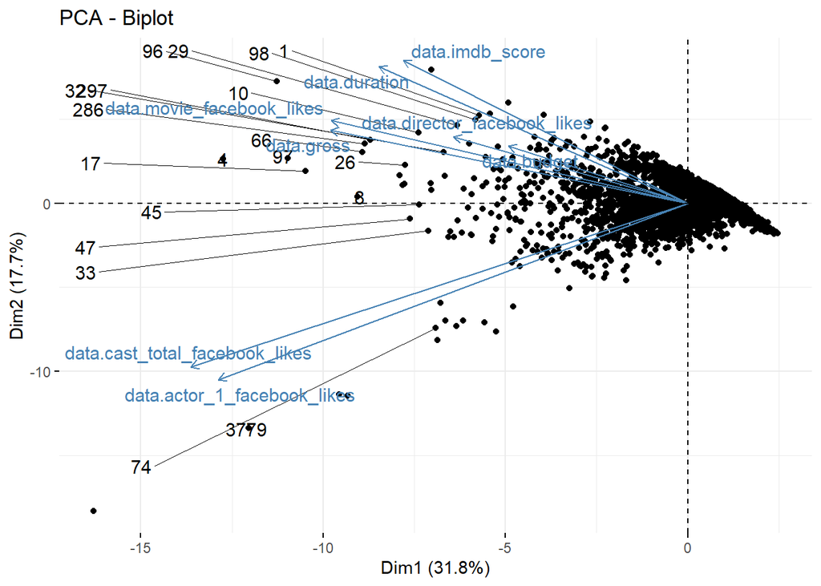

```r
fviz_pca_biplot(pca, repel = TRUE)
```

Again, this plot shows the importance of likes (mainly actor 1), then gross and, finally, IMDb score.

**Final analysis**

As the question to be answered is which factor is more beneficial to a movie’s success (either social media, economic motives or online score), the following plots can be created to see if this variables really affect to the outcome.

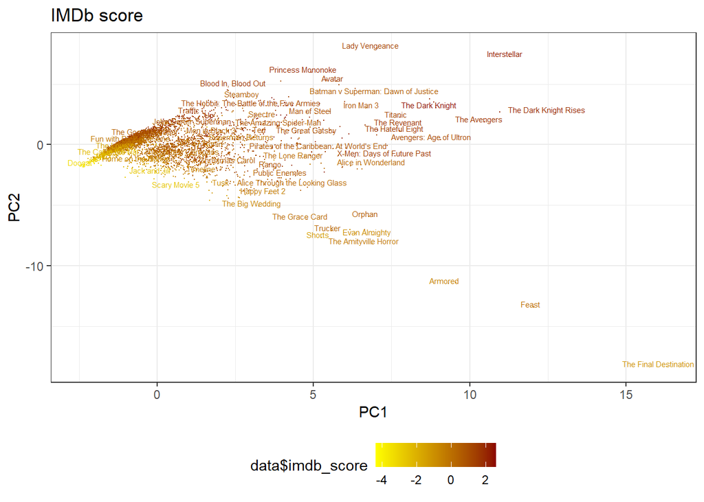

```r
data.frame(z1=-pca$x[,1],z2=pca$x[,2]) %>%
  ggplot(aes(z1,z2,label=titles,color=data$imdb_score)) + geom_point(size=0) +
  labs(title="IMDb score", x="PC1", y="PC2") +
  theme_bw() + scale_color_gradient(low="yellow", high="darkred")+
  theme(legend.position="bottom") +
  geom_text(size=2, hjust=0.6, vjust=0, check_overlap = TRUE)
```

The IMDb score graph shows that the gradient is not regular, what means that online score is not that important when defining a movie as successful.

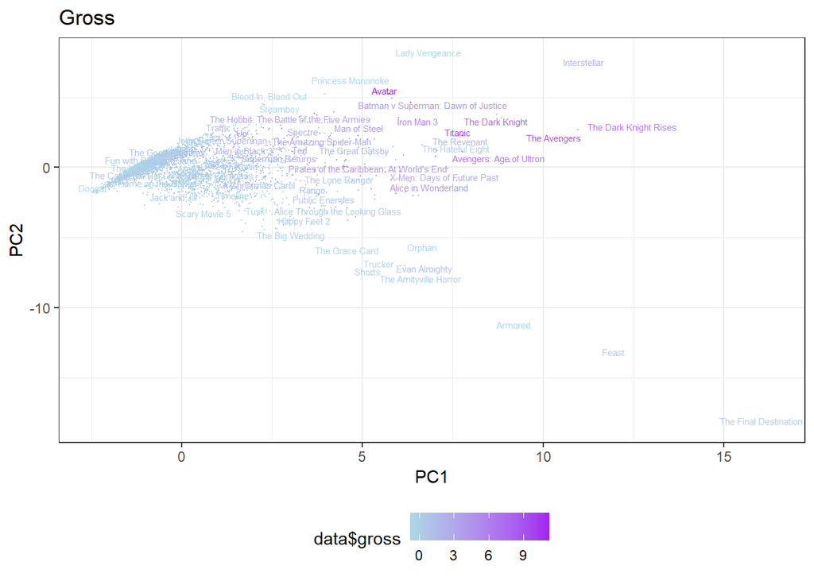

```r
data.frame(z1=-pca$x[,1],z2=pca$x[,2]) %>%
  ggplot(aes(z1,z2,label=titles,color=data$gross)) + geom_point(size=0) +
  labs(title="Gross", x="PC1", y="PC2") +
  theme_bw() + scale_color_gradient(low="lightblue", high="purple")+
  theme(legend.position="bottom") +
  geom_text(size=2, hjust=0.6, vjust=0, check_overlap = TRUE)
```

About the gross, it is clear that it is more related than IMDb score. However, still very successful films have a blue tone while there are purple movies that do not represent part of the best group.

Although there were four variables about social media impact, PCA has demonstrated that the main actor’s likes are the most important factor so the plot is going to be created with that variable.

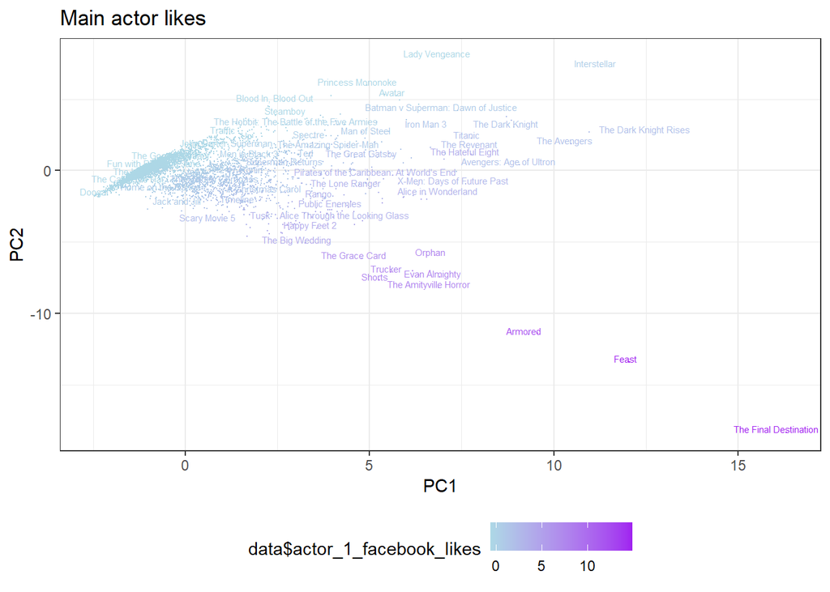

```r
data.frame(z1=-pca$x[,1],z2=pca$x[,2]) %>%
  ggplot(aes(z1,z2,label=titles,color=data$actor_1_facebook_likes)) + geom_point(size=0) +
  labs(title="Main actor likes", x="PC1", y="PC2") +
  theme_bw() + scale_color_gradient(low="lightblue", high="purple")+
  theme(legend.position="bottom") +
  geom_text(size=2, hjust=0.6, vjust=0, check_overlap = TRUE)
```

Taking all the previous analysis into consideration, PCA has demonstrated that social media is the most important factor to make a film successful. After that, gross, and finally, online score.

**Best directors, actors, countries and years**

With the PCA constructed, the best directors, actors, countries and years can be computed.

```r
data.frame(z1=-pca$x[,1],directors=directors) %>%
  group_by(directors) %>% summarise(mean=mean(z1)) %>% arrange(desc(mean))
```

```
## # A tibble: 2,165 x 2
##    directors            mean
##    <chr>               <dbl>
##  1 John Gulager        12.0
##  2 Christopher Nolan    7.59
##  3 Andrew Douglas       6.87
##  4 Florent-Emilio Siri  6.64
##  5 Joss Whedon          6.53
##  6 James Mottern        5.58
##  7 Rupert Sanders       4.89
##  8 Tim Miller           4.88
##  9 David G. Evans       4.79
## 10 Francis Lawrence     4.77
## # ... with 2,155 more rows
```

```r
data.frame(z1=-pca$x[,1],actors=actors) %>%
  group_by(actors) %>% summarise(mean=mean(z1)) %>% arrange(desc(mean))
```

```
## # A tibble: 1,858 x 2
##    actors             mean
##    <chr>             <dbl>
##  1 Krista Allen      14.2
##  2 Andrew Fiscella    9.44
##  3 Craig Stark        7.81
##  4 Tim Holmes         6.40
##  5 Jimmy Bennett      6.32
##  6 Peter Capaldi      4.90
##  7 Michael Joiner     4.79
##  8 Leonardo DiCaprio  4.77
##  9 Jennifer Lawrence  4.71
## 10 Chris Hemsworth    4.01
## # ... with 1,848 more rows
```

```r
data.frame(z1=-pca$x[,1],countries=countries) %>%
  group_by(countries) %>% summarise(mean=mean(z1)) %>% arrange(desc(mean))
```

```
## # A tibble: 58 x 2
##    countries      mean
##    <chr>         <dbl>
##  1 Hungary      1.59
##  2 Panama       1.21
##  3 West Germany 0.616
##  4 New Zealand  0.555
##  5 Japan        0.502
##  6 Libya        0.442
##  7 Belgium      0.365
##  8 South Korea  0.227
##  9 Indonesia    0.106
## 10 USA          0.0831
## # ... with 48 more rows
```

```r
data.frame(z1=-pca$x[,1],years=years) %>%
  group_by(years) %>% summarise(mean=mean(z1)) %>% arrange(desc(mean))
```

```
## # A tibble: 88 x 2
##    years  mean
##    <dbl> <dbl>
##  1  1939 0.666
##  2  1973 0.605
##  3  2013 0.568
##  4  2016 0.520
##  5  2015 0.519
##  6  1975 0.516
##  7  1976 0.424
##  8  1990 0.415
##  9  2014 0.359
## 10  2012 0.356
## # ... with 78 more rows
```

Regarding actors and directors, they are the ones that appear on the top films of the PCA analysis, so there are no surprises. Also, they coincide with the ones that appeared on the graphs computed in the beginning.

However, about the years and countries there are some unexpected results. About the countries, USA appears on the tenth place, lower than expected. An explanation can be that many films are produced in that country so, although there are very successful ones, there are many others that do not accomplish good results. However, other countries with less films obtain proportionally better results. This is the case, for example, of Japan, that was already seen in the graph to be successful. The same happens with years, it alternates old years, that seem worse at first sight, with recent ones. Having said that, it is probable that older years have less films but with better results, contrary to more recent years. This was seen in the graphs computed in point 2, where really old films had very high IMDb scores.

# 4. Factor Analysis

Factor analysis is a technique that has a similar objective to PCA’s one. Its goal is to reduce the number of variables of a dataset into a fewer number of factors. It uses the variability and correlation of variables.

As in PCA it was already found that we need 4 factors with the scree plot, factor analysis will be done with that number.

**No rotation and regression scores**

```r
x.f <- factanal(dataframe, factors = 4, rotation="none", scores="regression")
x.f
```

```
##
## Call:
## factanal(x = dataframe, factors = 4, scores = "regression", rotation = "none")
##
## Uniquenesses:
##                     data.gross                  data.duration
##                          0.382                          0.715
##   data.director_facebook_likes    data.actor_1_facebook_likes
##                          0.906                          0.005
## data.cast_total_facebook_likes                    data.budget
##                          0.005                          0.920
##                data.imdb_score      data.movie_facebook_likes
##                          0.503                          0.729
##
## Loadings:
##                                Factor1 Factor2 Factor3 Factor4
## data.gross                      0.240   0.584  -0.389   0.262
## data.duration                   0.152   0.450   0.224
## data.director_facebook_likes    0.147   0.233   0.119
## data.actor_1_facebook_likes     0.982                  -0.178
## data.cast_total_facebook_likes  0.982                   0.176
## data.budget                             0.214  -0.136
## data.imdb_score                 0.122   0.540   0.436
## data.movie_facebook_likes       0.232   0.419           0.203
##
##                Factor1 Factor2 Factor3 Factor4
## SS loadings      2.107   1.112   0.424   0.192
## Proportion Var   0.263   0.139   0.053   0.024
## Cumulative Var   0.263   0.402   0.455   0.479
##
## Test of the hypothesis that 4 factors are sufficient.
## The chi square statistic is 38.93 on 2 degrees of freedom.
## The p-value is 3.51e-09
```

Both the uniqueness and loadings have to be studied:

On the one hand, regarding uniqueness, the closer to 1 the worse it explains the model. In this case, there are two variables with an uniqueness closer to 1: the budget and the director Facebook likes. Also, there are two variables with values close to 0: the cast Facebook likes and the actor 1 Facebook likes.

On the other hand, regarding loadings, the closer to 1, the better representation of the model, contrary to being closer to -1. Although there are 4 different factor values, as SS loadings are bigger than 1 in factors 1 and 2, these are better, specially 1 which is bigger than 2. In this factor, the actor 1 Facebook likes and cast total Facebook likes are really close to 1, so they are good variables. There are no negative variables but IMDb score, the director Facebook likes and the duration have small values.

These conclusions can be better analysed with the cbind function that combines the results of all factors into one.

```r
cbind(x.f$loadings, x.f$uniquenesses)
```

```
##                                   Factor1      Factor2      Factor3     Factor4
## data.gross                     0.23965305  0.584025735 -0.388607021  0.26181909
## data.duration                  0.15198353  0.450474277  0.223782316  0.09503402
## data.director_facebook_likes   0.14692345  0.233166101  0.118811525  0.05961199
## data.actor_1_facebook_likes    0.98150491  0.006953072 -0.002945424 -0.17773890
## data.cast_total_facebook_likes 0.98172411 -0.010957930  0.003383749  0.17631294
## data.budget                    0.09368578  0.213946080 -0.136392703  0.08225435
## data.imdb_score                0.12224823  0.540317520  0.435628612  0.02083219
## data.movie_facebook_likes      0.23234403  0.418960353 -0.003714676  0.20275559
##
## data.gross                     0.3819154
## data.duration                  0.7148570
## data.director_facebook_likes   0.9063826
## data.actor_1_facebook_likes    0.0050000
## data.cast_total_facebook_likes 0.0050000
## data.budget                    0.9200860
## data.imdb_score                0.5029049
## data.movie_facebook_likes      0.7293626
```

The values that are close to 0 are good representations, but only the actor 1 Facebook likes and the cast Facebook likes are close to this value. The lowest value after them is the one given by the gross and after, the IMDb score. Finally, the worst variables are the budget and the director Facebook likes.

Now, let’s graphically see the results with barplots.

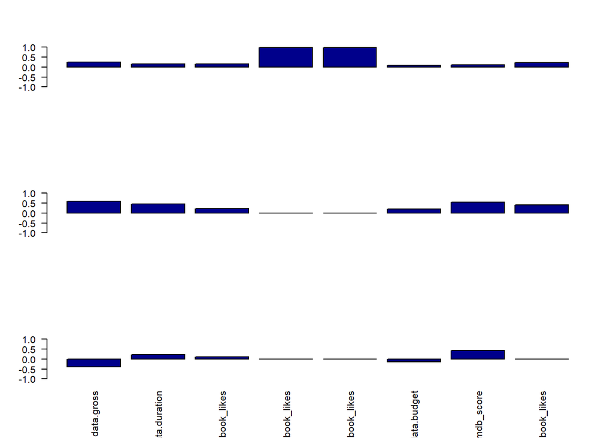

```r
par(mfrow=c(3,1))
barplot(x.f$loadings[,1], names=F, las=2, col="darkblue", ylim = c(-1, 1))
barplot(x.f$loadings[,2], names=F, las=2, col="darkblue", ylim = c(-1, 1))
barplot(x.f$loadings[,3], las=2, col="darkblue", ylim = c(-1, 1))
```

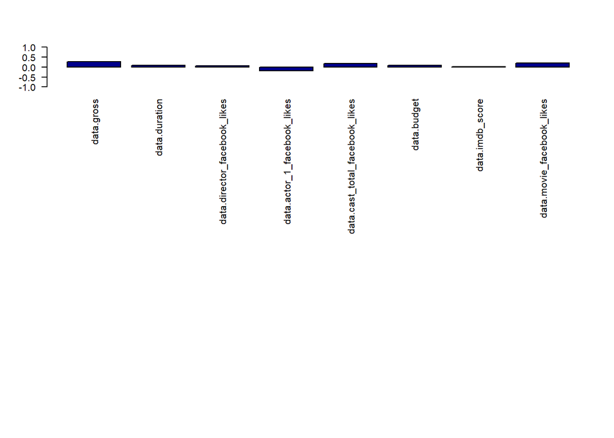

```r
barplot(x.f$loadings[,4], las=2, col="darkblue", ylim = c(-1, 1))
```

To check the results, another technique is going to be applied and analysed to see if the conclusions were correct.

**Varimax rotation and Bartlett scores**

```r
x.f <- factanal(dataframe, factors = 4, rotation="varimax", scores="Bartlett", lower = 0.01)
x.f
```

```
##
## Call:
## factanal(x = dataframe, factors = 4, scores = "Bartlett", rotation = "varimax",     lower = 0.01)
##
## Uniquenesses:
##                     data.gross                  data.duration
##                          0.556                          0.660
##   data.director_facebook_likes    data.actor_1_facebook_likes
##                          0.906                          0.109
## data.cast_total_facebook_likes                    data.budget
##                          0.010                          0.839
##                data.imdb_score      data.movie_facebook_likes
##                          0.510                          0.618
##
## Loadings:
##                                Factor1 Factor2 Factor3 Factor4
## data.gross                      0.123   0.161   0.474   0.422
## data.duration                           0.514           0.252
## data.director_facebook_likes            0.251   0.134
## data.actor_1_facebook_likes     0.931   0.119
## data.cast_total_facebook_likes  0.965   0.103   0.186   0.119
## data.budget                                             0.386
## data.imdb_score                         0.683   0.149
## data.movie_facebook_likes       0.123   0.267   0.530   0.119
##
##                Factor1 Factor2 Factor3 Factor4
## SS loadings      1.844   0.921   0.601   0.426
## Proportion Var   0.231   0.115   0.075   0.053
## Cumulative Var   0.231   0.346   0.421   0.474
##
## Test of the hypothesis that 4 factors are sufficient.
## The chi square statistic is 14.91 on 2 degrees of freedom.
## The p-value is 0.00058
```

Basically, the conclusions that can be drawn from this proceeding are the same as the ones obtained with the other method. Because of the SS loadings, the first factor is the most important one. In it, the variables with uniqueness close to 0 and loadings close to 1 are the main actor and cast Facebook likes. What means that again, these are the most principal. Then, the worst are the director Facebook likes and the budget as before.

Let’s combine them with cbind function.

```r
cbind(x.f$loadings, x.f$uniquenesses)
```

```
##                                   Factor1    Factor2    Factor3     Factor4
## data.gross                     0.12303638 0.16087355 0.47402904  0.42173405
## data.duration                  0.06379836 0.51409965 0.09017986  0.25223016
## data.director_facebook_likes   0.09837118 0.25149611 0.13355046  0.05810804
## data.actor_1_facebook_likes    0.93141925 0.11904383 0.07877013  0.05633384
## data.cast_total_facebook_likes 0.96470379 0.10276375 0.18604700  0.11905268
## data.budget                    0.03837871 0.06453171 0.07933905  0.38591647
## data.imdb_score                0.02395395 0.68340000 0.14946288 -0.01304255
## data.movie_facebook_likes      0.12325580 0.26712698 0.53026051  0.11947715
##
## data.gross                     0.5564174
## data.duration                  0.6598878
## data.director_facebook_likes   0.9058318
## data.actor_1_facebook_likes    0.1089078
## data.cast_total_facebook_likes 0.0100000
## data.budget                    0.8391155
## data.imdb_score                0.5098882
## data.movie_facebook_likes      0.6179918
```

The same conclusions arise, the variables with values close to 0 (good variables) are the cast and actor 1 Facebook likes and the closest to 1 (worst variables) are the director Facebook likes and the budget.

Finally, the plots can be computed.

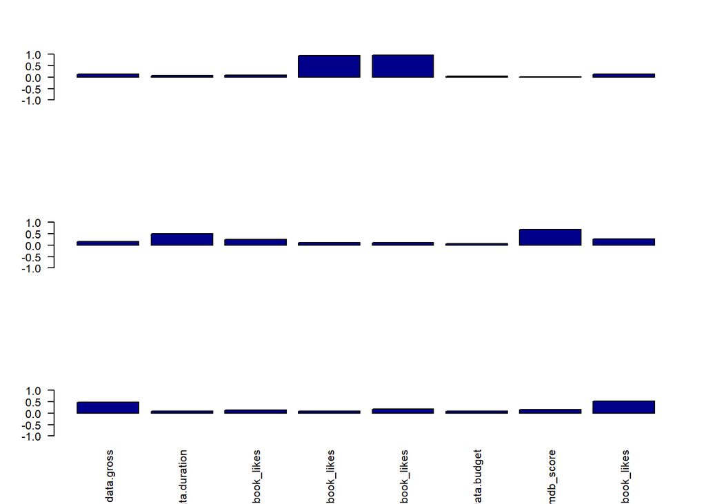

```r
par(mfrow=c(3,1))
barplot(x.f$loadings[,1], names=F, las=2, col="darkblue", ylim = c(-1, 1))
barplot(x.f$loadings[,2], names=F, las=2, col="darkblue", ylim = c(-1, 1))
barplot(x.f$loadings[,3], las=2, col="darkblue", ylim = c(-1, 1))
```

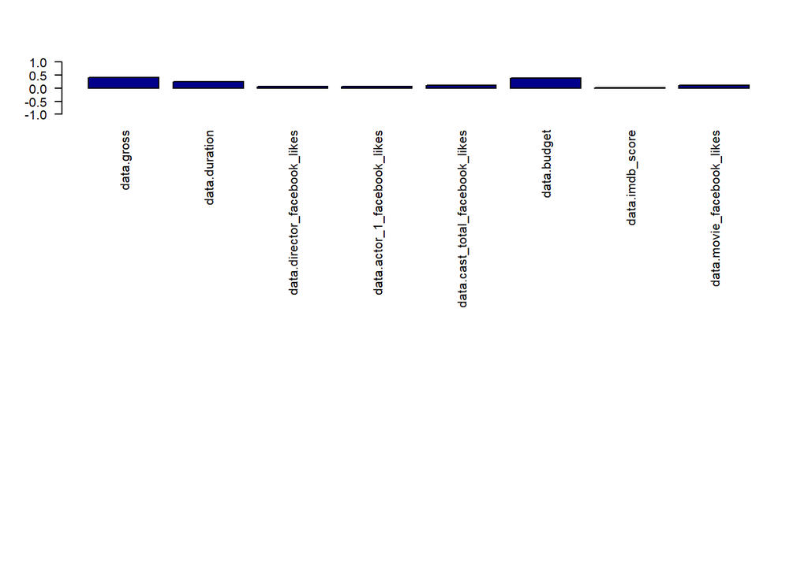

```r
barplot(x.f$loadings[,4], las=2, col="darkblue", ylim = c(-1, 1))
```

Taking into account all this information, plus the one obtained in the Principal Component Analysis, it is clear that social media is a crucial factor when making a successful movie. On top of this, the cast is very important, as the top likes are the ones of the main actor and cast. After that, the other important factor is the gross and, finally, the IMDb score.

# 5. Clustering

Clustering is a technique that groups the data based on their similarity, so the data that belong to a same group (cluster) have common characteristics.

There are several techniques that can be applied to compute the clustering.

**Kmeans**

- Choosing the number of centers

There are three ways of computing the optimal number of clusters.

The first one is called WSS, which is based on the total within sum of squares.

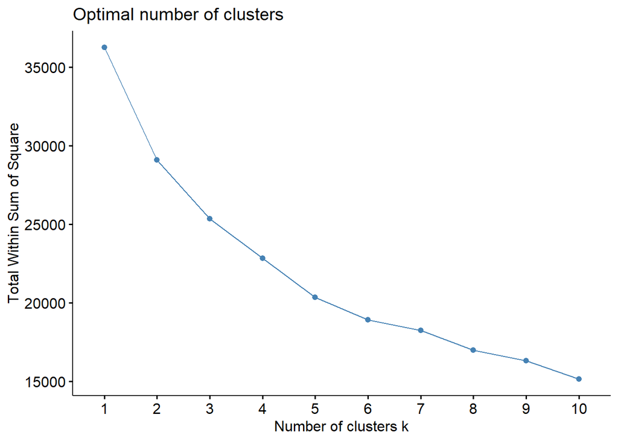

```r
fviz_nbclust(dataframe, kmeans, method = 'wss')
```

That previous technique seems to give 4 as optimum cluster number.

The second technique is called silhouette

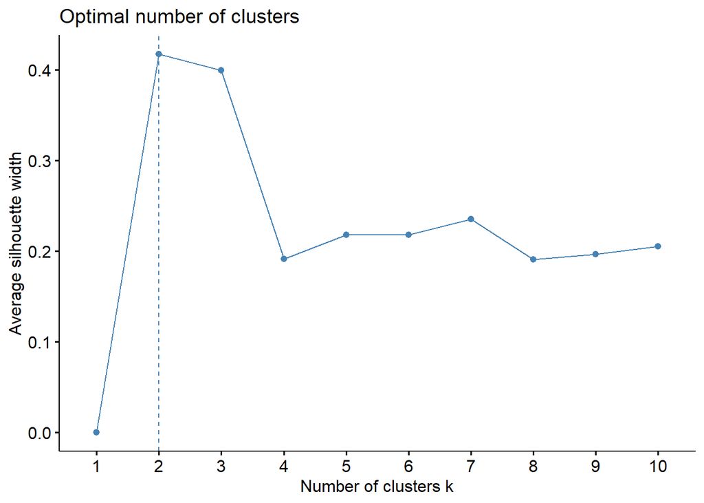

```r
fviz_nbclust(dataframe, kmeans, method = 'silhouette')
```

This method gives 2 clusters as a result

Lastly, the third one is called gap statistic, and it uses bootstrap.

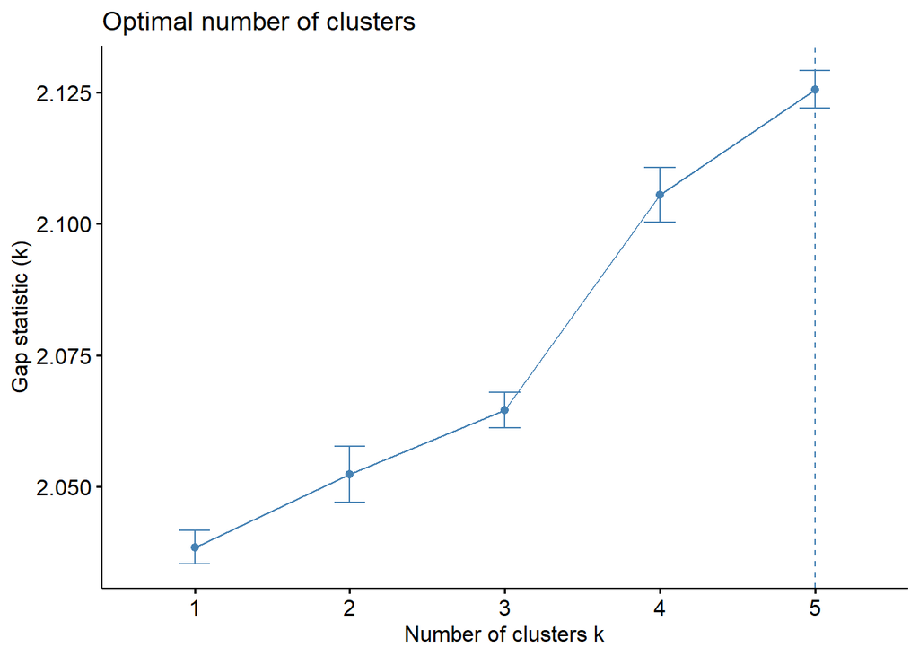

```r
fviz_nbclust(dataframe, kmeans, method = 'gap_stat', k.max = 5)
```

This technique gives as a result 5 clusters

I will use this last technique to compute the clusters.